# exploratory

## Prosper Loan Data Exploration

### Data Wrangling

- This document will explore a dataset for prosper Loan

```python
# import all packages and set plots to be embedded inline
import numpy as np
import pandas as pd
import matplotlib.pyplot as plt
import seaborn as sb

%matplotlib inline
```

```python
df = pd.read_csv('prosperLoanData.csv') # Reading My csv file in Jupyter Notebook
```

```python
df.head(10) #Show the first 10 Rows
```

|  | ListingKey | ListingNumber | ListingCreationDate | CreditGrade | Term | LoanStatus | ClosedDate | BorrowerAPR | BorrowerRate | LenderYield | ... | LP_ServiceFees | LP_CollectionFees | LP_GrossPrincipalLoss | LP_NetPrincipalLoss | LP_NonPrincipalRecoverypayments | PercentFunded | Recommendations | InvestmentFromFriendsCount | InvestmentFromFriendsAmount | Investors |
| --- | --- | --- | --- | --- | --- | --- | --- | --- | --- | --- | --- | --- | --- | --- | --- | --- | --- | --- | --- | --- | --- |
| 0 | 1021339766868145413AB3B | 193129 | 2007-08-26 19:09:29.263000000 | C | 36 | Completed | 2009-08-14 00:00:00 | 0.16516 | 0.1580 | 0.1380 | ... | -133.18 | 0.0 | 0.0 | 0.0 | 0.0 | 1.0 | 0 | 0 | 0.0 | 258 |
| 1 | 10273602499503308B223C1 | 1209647 | 2014-02-27 08:28:07.900000000 | NaN | 36 | Current | NaN | 0.12016 | 0.0920 | 0.0820 | ... | 0.00 | 0.0 | 0.0 | 0.0 | 0.0 | 1.0 | 0 | 0 | 0.0 | 1 |
| 2 | 0EE9337825851032864889A | 81716 | 2007-01-05 15:00:47.090000000 | HR | 36 | Completed | 2009-12-17 00:00:00 | 0.28269 | 0.2750 | 0.2400 | ... | -24.20 | 0.0 | 0.0 | 0.0 | 0.0 | 1.0 | 0 | 0 | 0.0 | 41 |
| 3 | 0EF5356002482715299901A | 658116 | 2012-10-22 11:02:35.010000000 | NaN | 36 | Current | NaN | 0.12528 | 0.0974 | 0.0874 | ... | -108.01 | 0.0 | 0.0 | 0.0 | 0.0 | 1.0 | 0 | 0 | 0.0 | 158 |
| 4 | 0F023589499656230C5E3E2 | 909464 | 2013-09-14 18:38:39.097000000 | NaN | 36 | Current | NaN | 0.24614 | 0.2085 | 0.1985 | ... | -60.27 | 0.0 | 0.0 | 0.0 | 0.0 | 1.0 | 0 | 0 | 0.0 | 20 |
| 5 | 0F05359734824199381F61D | 1074836 | 2013-12-14 08:26:37.093000000 | NaN | 60 | Current | NaN | 0.15425 | 0.1314 | 0.1214 | ... | -25.33 | 0.0 | 0.0 | 0.0 | 0.0 | 1.0 | 0 | 0 | 0.0 | 1 |
| 6 | 0F0A3576754255009D63151 | 750899 | 2013-04-12 09:52:56.147000000 | NaN | 36 | Current | NaN | 0.31032 | 0.2712 | 0.2612 | ... | -22.95 | 0.0 | 0.0 | 0.0 | 0.0 | 1.0 | 0 | 0 | 0.0 | 1 |
| 7 | 0F1035772717087366F9EA7 | 768193 | 2013-05-05 06:49:27.493000000 | NaN | 36 | Current | NaN | 0.23939 | 0.2019 | 0.1919 | ... | -69.21 | 0.0 | 0.0 | 0.0 | 0.0 | 1.0 | 0 | 0 | 0.0 | 1 |
| 8 | 0F043596202561788EA13D5 | 1023355 | 2013-12-02 10:43:39.117000000 | NaN | 36 | Current | NaN | 0.07620 | 0.0629 | 0.0529 | ... | -16.77 | 0.0 | 0.0 | 0.0 | 0.0 | 1.0 | 0 | 0 | 0.0 | 1 |
| 9 | 0F043596202561788EA13D5 | 1023355 | 2013-12-02 10:43:39.117000000 | NaN | 36 | Current | NaN | 0.07620 | 0.0629 | 0.0529 | ... | -16.77 | 0.0 | 0.0 | 0.0 | 0.0 | 1.0 | 0 | 0 | 0.0 | 1 |

10 rows × 81 columns

```python
df.shape # the shape of dataset
```

```
(113937, 81)
```

```python
df.ListingKey.nunique()
```

```
113066
```

```python
df.info() #Information for my dataset and its Columns
```

```
<class 'pandas.core.frame.DataFrame'>
RangeIndex: 113937 entries, 0 to 113936
Data columns (total 81 columns):
 #   Column                               Non-Null Count   Dtype
---  ------                               --------------   -----
 0   ListingKey                           113937 non-null  object
 1   ListingNumber                        113937 non-null  int64
 2   ListingCreationDate                  113937 non-null  object
 3   CreditGrade                          28953 non-null   object
 4   Term                                 113937 non-null  int64
 5   LoanStatus                           113937 non-null  object
 6   ClosedDate                           55089 non-null   object
 7   BorrowerAPR                          113912 non-null  float64
 8   BorrowerRate                         113937 non-null  float64
 9   LenderYield                          113937 non-null  float64
```

[output cut: 73 more lines]

```python
prosper_loan= df.loc[:, ['ListingCreationDate', 'Term', 'LoanStatus', 'ClosedDate', 'BorrowerAPR',
                         'BorrowerRate', 'LenderYield', 'ProsperRating (Alpha)', 'ProsperScore', 'ListingCategory (numeric)',
                         'BorrowerState', 'Occupation', 'EmploymentStatus', 'AmountDelinquent',
                         'IncomeRange', 'StatedMonthlyIncome',
                         'LoanCurrentDaysDelinquent',
                         'LoanOriginalAmount', 'LoanOriginationDate',
                         'MonthlyLoanPayment', 'LP_ServiceFees', 'Investors']]
#These columns are related to the amount of loan, dates, rates and other charactrestics about the borrowers.
```

```python
prosper_loan.info()
```

```
<class 'pandas.core.frame.DataFrame'>
RangeIndex: 113937 entries, 0 to 113936
Data columns (total 22 columns):
 #   Column                     Non-Null Count   Dtype
---  ------                     --------------   -----
 0   ListingCreationDate        113937 non-null  object
 1   Term                       113937 non-null  int64
 2   LoanStatus                 113937 non-null  object
 3   ClosedDate                 55089 non-null   object
 4   BorrowerAPR                113912 non-null  float64
 5   BorrowerRate               113937 non-null  float64
 6   LenderYield                113937 non-null  float64
 7   ProsperRating (Alpha)      84853 non-null   object
 8   ProsperScore               84853 non-null   float64
 9   ListingCategory (numeric)  113937 non-null  int64
 10  BorrowerState              108422 non-null  object
 11  Occupation                 110349 non-null  object
 12  EmploymentStatus           111682 non-null  object
 13  AmountDelinquent           106315 non-null  float64
 14  IncomeRange                113937 non-null  object
 15  StatedMonthlyIncome        113937 non-null  float64
 16  LoanCurrentDaysDelinquent  113937 non-null  int64
 17  LoanOriginalAmount         113937 non-null  int64
 18  LoanOriginationDate        113937 non-null  object
 19  MonthlyLoanPayment         113937 non-null  float64
 20  LP_ServiceFees             113937 non-null  float64
 21  Investors                  113937 non-null  int64
dtypes: float64(8), int64(5), object(9)
memory usage: 19.1+ MB
```

```python
prosper_loan.duplicated().sum() #to check How many Duplicate data
```

```
0
```

There is nothing

```python
prosper_loan.isna().sum()
```

```
ListingCreationDate              0
Term                             0
LoanStatus                       0
ClosedDate                   58848
BorrowerAPR                     25
BorrowerRate                     0
LenderYield                      0
ProsperRating (Alpha)        29084
ProsperScore                 29084
ListingCategory (numeric)        0
BorrowerState                 5515
Occupation                    3588
EmploymentStatus              2255
AmountDelinquent              7622
IncomeRange                      0
StatedMonthlyIncome              0
LoanCurrentDaysDelinquent        0
LoanOriginalAmount               0
LoanOriginationDate              0
MonthlyLoanPayment               0
LP_ServiceFees                   0
Investors                        0
dtype: int64
```

- I have missing data in Closed Date , ProsperRating , Borrower State , Occupation , Employment Status and Amount Delingauent

```python
prosper_loan.head()
```

|  | ListingCreationDate | Term | LoanStatus | ClosedDate | BorrowerAPR | BorrowerRate | LenderYield | ProsperRating (Alpha) | ProsperScore | ListingCategory (numeric) | ... | EmploymentStatus | AmountDelinquent | IncomeRange | StatedMonthlyIncome | LoanCurrentDaysDelinquent | LoanOriginalAmount | LoanOriginationDate | MonthlyLoanPayment | LP_ServiceFees | Investors |
| --- | --- | --- | --- | --- | --- | --- | --- | --- | --- | --- | --- | --- | --- | --- | --- | --- | --- | --- | --- | --- | --- |
| 0 | 2007-08-26 19:09:29.263000000 | 36 | Completed | 2009-08-14 00:00:00 | 0.16516 | 0.1580 | 0.1380 | NaN | NaN | 0 | ... | Self-employed | 472.0 | $25,000-49,999 | 3083.333333 | 0 | 9425 | 2007-09-12 00:00:00 | 330.43 | -133.18 | 258 |
| 1 | 2014-02-27 08:28:07.900000000 | 36 | Current | NaN | 0.12016 | 0.0920 | 0.0820 | A | 7.0 | 2 | ... | Employed | 0.0 | $50,000-74,999 | 6125.000000 | 0 | 10000 | 2014-03-03 00:00:00 | 318.93 | 0.00 | 1 |
| 2 | 2007-01-05 15:00:47.090000000 | 36 | Completed | 2009-12-17 00:00:00 | 0.28269 | 0.2750 | 0.2400 | NaN | NaN | 0 | ... | Not available | NaN | Not displayed | 2083.333333 | 0 | 3001 | 2007-01-17 00:00:00 | 123.32 | -24.20 | 41 |
| 3 | 2012-10-22 11:02:35.010000000 | 36 | Current | NaN | 0.12528 | 0.0974 | 0.0874 | A | 9.0 | 16 | ... | Employed | 10056.0 | $25,000-49,999 | 2875.000000 | 0 | 10000 | 2012-11-01 00:00:00 | 321.45 | -108.01 | 158 |
| 4 | 2013-09-14 18:38:39.097000000 | 36 | Current | NaN | 0.24614 | 0.2085 | 0.1985 | D | 4.0 | 2 | ... | Employed | 0.0 | $100,000+ | 9583.333333 | 0 | 15000 | 2013-09-20 00:00:00 | 563.97 | -60.27 | 20 |

5 rows × 22 columns

## Quality Issue

- LitingCreate Date , ClosedDate and LoanOriginationDate need to change in Date Time column
- Missing Data in Columns ( ProsperRating (Alpha) - ProsperScore - BorrowerState - Occupation - EmploymentStatus - AmountDelinquent )
- Emplyment Status - ListingCategory - LoanStatus must be in Categorical
- ProsperScore score range from 0 - 10 there is outlier 11

```python
prosper_loan.shape
```

```
(113937, 22)
```

```python
prosper_loan.Term.value_counts()
```

```
36    87778
60    24545
12     1614
Name: Term, dtype: int64
```

```python
prosper_loan.LoanStatus.value_counts()
```

```
Current                   56576
Completed                 38074
Chargedoff                11992
Defaulted                  5018
Past Due (1-15 days)        806
Past Due (31-60 days)       363
Past Due (61-90 days)       313
Past Due (91-120 days)      304
Past Due (16-30 days)       265
FinalPaymentInProgress      205
Past Due (>120 days)         16
Cancelled                     5
Name: LoanStatus, dtype: int64
```

```python
(prosper_loan.BorrowerAPR>=1).sum() # this is a percentage to check there is nothing exceed 1
```

```
0
```

```python
(prosper_loan.BorrowerRate>=1).sum() # this is a percentage to check there is nothing exceed 1
```

```
0
```

```python
(prosper_loan.LenderYield>=1).sum() # this is a percentage to check there is nothing exceed 1
```

```
0
```

```python
prosper_loan['ProsperRating (Alpha)'].value_counts()
```

```
C     18345
B     15581
A     14551
D     14274
E      9795
HR     6935
AA     5372
Name: ProsperRating (Alpha), dtype: int64
```

```python
prosper_loan.ProsperScore.value_counts() #the score range from 1 - 10 So 11 is not in our level
```

```
4.0     12595
6.0     12278
8.0     12053
7.0     10597
5.0      9813
3.0      7642
9.0      6911
2.0      5766
10.0     4750
11.0     1456
1.0       992
Name: ProsperScore, dtype: int64
```

```python
prosper_loan = prosper_loan[prosper_loan.ProsperScore <= 10]
```

It is supposed it is has been done

```python
prosper_loan.shape  #checking shape of my new data
```

```
(83397, 22)
```

There is more than 1456 and missing data

```python
prosper_loan.ProsperScore.value_counts()
```

```
4.0     12595
6.0     12278
8.0     12053
7.0     10597
5.0      9813
3.0      7642
9.0      6911
2.0      5766
10.0     4750
1.0       992
Name: ProsperScore, dtype: int64
```

```python
prosper_loan.BorrowerState.value_counts()
```

```
CA    10517
NY     5727
TX     5533
FL     5321
IL     4180
OH     3324
GA     3286
VA     2729
NJ     2681
PA     2632
MI     2585
NC     2399
MD     2215
WA     2117
MA     1793
MO     1770
CO     1697
MN     1682
IN     1626
TN     1516
WI     1493
CT     1467
AZ     1333
OR     1193
AL     1173
NV     1013
SC      976
KY      873
KS      846
LA      832
AR      765
OK      720
MS      668
NE      548
UT      515
NH      441
RI      406
ID      397
HI      332
NM      328
DC      320
WV      307
DE      261
MT      218
SD      188
VT      170
AK      165
WY      119
Name: BorrowerState, dtype: int64
```

```python
prosper_loan.EmploymentStatus.value_counts()
```

```
Employed         65945
Full-time         7913
Self-employed     4495
Other             3772
Not employed       649
Retired            367
Part-time          256
Name: EmploymentStatus, dtype: int64
```

```python
prosper_loan['ListingCreationDate'] = pd.to_datetime(prosper_loan['ListingCreationDate']) #Convert Columns to Date Time
prosper_loan['ClosedDate'] = pd.to_datetime(prosper_loan['ClosedDate'])
prosper_loan['LoanOriginationDate'] = pd.to_datetime(prosper_loan['LoanOriginationDate'])
```

```python
prosper_loan.info()
```

```
<class 'pandas.core.frame.DataFrame'>
Int64Index: 83397 entries, 1 to 113936
Data columns (total 22 columns):
 #   Column                     Non-Null Count  Dtype
---  ------                     --------------  -----
 0   ListingCreationDate        83397 non-null  datetime64[ns]
 1   Term                       83397 non-null  int64
 2   LoanStatus                 83397 non-null  object
 3   ClosedDate                 25973 non-null  datetime64[ns]
 4   BorrowerAPR                83397 non-null  float64
 5   BorrowerRate               83397 non-null  float64
 6   LenderYield                83397 non-null  float64
 7   ProsperRating (Alpha)      83397 non-null  object
 8   ProsperScore               83397 non-null  float64
 9   ListingCategory (numeric)  83397 non-null  int64
 10  BorrowerState              83397 non-null  object
 11  Occupation                 82084 non-null  object
 12  EmploymentStatus           83397 non-null  object
 13  AmountDelinquent           83397 non-null  float64
 14  IncomeRange                83397 non-null  object
 15  StatedMonthlyIncome        83397 non-null  float64
 16  LoanCurrentDaysDelinquent  83397 non-null  int64
 17  LoanOriginalAmount         83397 non-null  int64
 18  LoanOriginationDate        83397 non-null  datetime64[ns]
 19  MonthlyLoanPayment         83397 non-null  float64
 20  LP_ServiceFees             83397 non-null  float64
 21  Investors                  83397 non-null  int64
dtypes: datetime64[ns](3), float64(8), int64(5), object(6)
memory usage: 14.6+ MB
```

### Converting is Done

```python
ordinal_var_dict = {'ProsperRating (Alpha)': ['N/A','HR','E','D','C', 'B', 'A', 'AA'],
                    'IncomeRange':['$0','$1-24,999','$25,000-49,999','$50,000-74,999','$75,000-99,999','$100,000+']}
for var in ordinal_var_dict:
    ordered_var = pd.api.types.CategoricalDtype(ordered = True, categories = ordinal_var_dict[var])
    prosper_loan[var] = prosper_loan[var].astype(ordered_var)
```

```python
prosper_loan.info()
```

```
<class 'pandas.core.frame.DataFrame'>
Int64Index: 83397 entries, 1 to 113936
Data columns (total 22 columns):
 #   Column                     Non-Null Count  Dtype
---  ------                     --------------  -----
 0   ListingCreationDate        83397 non-null  datetime64[ns]
 1   Term                       83397 non-null  int64
 2   LoanStatus                 83397 non-null  object
 3   ClosedDate                 25973 non-null  datetime64[ns]
 4   BorrowerAPR                83397 non-null  float64
 5   BorrowerRate               83397 non-null  float64
 6   LenderYield                83397 non-null  float64
 7   ProsperRating (Alpha)      83397 non-null  category
 8   ProsperScore               83397 non-null  float64
 9   ListingCategory (numeric)  83397 non-null  int64
 10  BorrowerState              83397 non-null  object
 11  Occupation                 82084 non-null  object
 12  EmploymentStatus           83397 non-null  object
 13  AmountDelinquent           83397 non-null  float64
 14  IncomeRange                82748 non-null  category
 15  StatedMonthlyIncome        83397 non-null  float64
 16  LoanCurrentDaysDelinquent  83397 non-null  int64
 17  LoanOriginalAmount         83397 non-null  int64
 18  LoanOriginationDate        83397 non-null  datetime64[ns]
 19  MonthlyLoanPayment         83397 non-null  float64
 20  LP_ServiceFees             83397 non-null  float64
 21  Investors                  83397 non-null  int64
dtypes: category(2), datetime64[ns](3), float64(8), int64(5), object(4)
memory usage: 13.5+ MB
```

```python
prosper_loan.IncomeRange.value_counts()
```

```
$50,000-74,999    25261
$25,000-49,999    24047
$100,000+         14565
$75,000-99,999    14183
$1-24,999          4647
$0                   45
Name: IncomeRange, dtype: int64
```

```python
prosper_loan['ProsperRating (Alpha)'].value_counts()
```

```
C      18320
B      15410
D      14274
A      14030
E       9795
HR      6935
AA      4633
N/A        0
Name: ProsperRating (Alpha), dtype: int64
```

```python
prosper_loan.info()
```

```
<class 'pandas.core.frame.DataFrame'>
Int64Index: 83397 entries, 1 to 113936
Data columns (total 22 columns):
 #   Column                     Non-Null Count  Dtype
---  ------                     --------------  -----
 0   ListingCreationDate        83397 non-null  datetime64[ns]
 1   Term                       83397 non-null  int64
 2   LoanStatus                 83397 non-null  object
 3   ClosedDate                 25973 non-null  datetime64[ns]
 4   BorrowerAPR                83397 non-null  float64
 5   BorrowerRate               83397 non-null  float64
 6   LenderYield                83397 non-null  float64
 7   ProsperRating (Alpha)      83397 non-null  category
 8   ProsperScore               83397 non-null  float64
 9   ListingCategory (numeric)  83397 non-null  int64
 10  BorrowerState              83397 non-null  object
 11  Occupation                 82084 non-null  object
 12  EmploymentStatus           83397 non-null  object
 13  AmountDelinquent           83397 non-null  float64
 14  IncomeRange                82748 non-null  category
 15  StatedMonthlyIncome        83397 non-null  float64
 16  LoanCurrentDaysDelinquent  83397 non-null  int64
 17  LoanOriginalAmount         83397 non-null  int64
 18  LoanOriginationDate        83397 non-null  datetime64[ns]
 19  MonthlyLoanPayment         83397 non-null  float64
 20  LP_ServiceFees             83397 non-null  float64
 21  Investors                  83397 non-null  int64
dtypes: category(2), datetime64[ns](3), float64(8), int64(5), object(4)
memory usage: 13.5+ MB
```

## What is the structure of your dataset?

- it is consist of 22 columns and 83397 Rows
- There is missing data in Closed Date more than 50K

```python
#Adjust datatype for all other categorical columns
prosper_loan['Occupation'] = prosper_loan['Occupation'].astype('category')
prosper_loan['BorrowerState'] = prosper_loan['BorrowerState'].astype('category')
prosper_loan['LoanStatus'] = prosper_loan['LoanStatus'].astype('category')
prosper_loan['ListingCategory (numeric)'] = prosper_loan['ListingCategory (numeric)'].astype('category')
prosper_loan['EmploymentStatus'] = prosper_loan['EmploymentStatus'].astype('category')
```

```python
base_color = sb.color_palette()[0]
n_employment = prosper_loan.EmploymentStatus.value_counts().sum()
max_n_employment = prosper_loan.EmploymentStatus.value_counts()[0]
max_prop_employment = max_n_employment / n_employment
employment_ticks = np.arange(0,max_prop_employment,0.1)
tick_names = ['{:0.2f}'.format(v) for v in employment_ticks]
```

## State of people who got loan

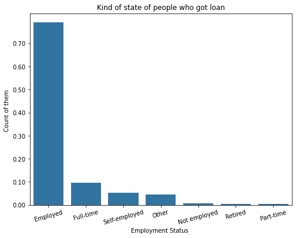

```python
plt.figure(figsize=(8, 6))
count_Employment = sb.countplot(data=prosper_loan,x='EmploymentStatus',order=prosper_loan.EmploymentStatus.value_counts().index,
                                color=base_color)
plt.yticks(employment_ticks*n_employment, tick_names)
plt.xticks(rotation=15);
plt.title("Kind of state of people who got loan")
plt.xlabel('Employment Status ')
plt.ylabel("Count of them ");
```

This Figure shows that most of people were emplyoment that will be reason for Security

### Distributaion of Terms between 1 year and 3 and 5 years

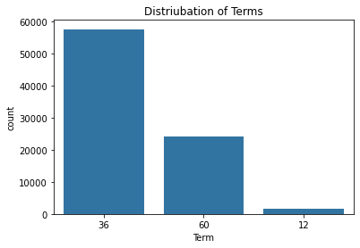

```python
term = sb.countplot(data=prosper_loan,x='Term',order=prosper_loan.Term.value_counts().index,color=base_color);
plt.title("Distriubation of Terms");
```

36 months is the most common perioed

```python
prosper_loan['ProsperRating (Alpha)']
```

```
1         A
3         A
4         D
5         B
6         E
         ..
113932    C
113933    A
113934    D
113935    C
113936    A
Name: ProsperRating (Alpha), Length: 83397, dtype: category
Categories (8, object): ['N/A' < 'HR' < 'E' < 'D' < 'C' < 'B' < 'A' < 'AA']
```

This figure shows that most of people prefered to get in 36 months

```python
n_ProsperRating = prosper_loan['ProsperRating (Alpha)'].value_counts().sum()
max_n_ProsperRating = prosper_loan['ProsperRating (Alpha)'].value_counts()[0]
max_prop_ProsperRating = max_n_ProsperRating / n_ProsperRating
ProsperRating_ticks = np.arange(0,max_prop_ProsperRating,0.02)
ProsperRating_names = ['{:0.2f}'.format(v) for v in ProsperRating_ticks]
```

```python
ProsperRating_names
```

```
['0.00',
 '0.02',
 '0.04',
 '0.06',
 '0.08',
 '0.10',
 '0.12',
 '0.14',
 '0.16',
 '0.18',
 '0.20']
```

### Prosper Rating Distriubation

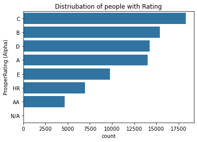

```python
prosper_rating = sb.countplot(data= prosper_loan, y= 'ProsperRating (Alpha)',
                             order=prosper_loan['ProsperRating (Alpha)'].value_counts().index,
                             color =base_color)
plt.title('Distriubation of people with Rating')
```

C is the most Rate common

Prosper Score Distribuation

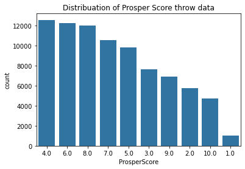

```python
sb.countplot(data=prosper_loan,x='ProsperScore',color=base_color,
            order=prosper_loan.ProsperScore.value_counts().index)
plt.title('Distribuation of Prosper Score throw data');
```

Prosper Scores are almost normally distributed and values 4, 6 ,8 and 7 are the most common.

2 plots show distribuation Borrower Rate and APR

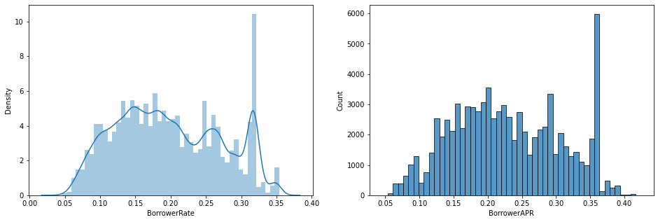

```python
plt.figure(figsize=[16,5])
plt.subplot(1, 2, 1)
sb.distplot(prosper_loan.BorrowerRate)
plt.subplot(1, 2, 2)
sb.histplot(prosper_loan.BorrowerAPR,bins=50);
```

- They 're seems like normal distriubted except that 0.30
- they 're seems like highly correlated

```python
prosper_loan[['BorrowerRate','BorrowerAPR']].corr() #correlation between them
```

|  | BorrowerRate | BorrowerAPR |
| --- | --- | --- |
| BorrowerRate | 1.000000 | 0.993168 |
| BorrowerAPR | 0.993168 | 1.000000 |

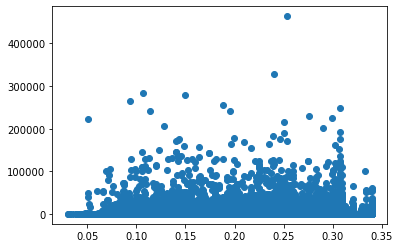

```python
plt.scatter(data=prosper_loan,x='LenderYield',y='AmountDelinquent')
```

```python
prosper_loan[['AmountDelinquent','LenderYield','BorrowerRate']].corr()
```

|  | AmountDelinquent | LenderYield | BorrowerRate |
| --- | --- | --- | --- |
| AmountDelinquent | 1.000000 | 0.050960 | 0.050955 |
| LenderYield | 0.050960 | 1.000000 | 0.999996 |
| BorrowerRate | 0.050955 | 0.999996 | 1.000000 |

### Prosper Rate and Borrower Rate

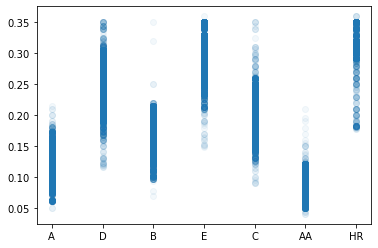

```python
plt.scatter(data=prosper_loan,x='ProsperRating (Alpha)',y='BorrowerRate',alpha=1/20);
```

```python
prosper_loan.describe()
```

|  | Term | BorrowerAPR | BorrowerRate | LenderYield | ProsperScore | AmountDelinquent | StatedMonthlyIncome | LoanCurrentDaysDelinquent | LoanOriginalAmount | MonthlyLoanPayment | LP_ServiceFees | Investors |
| --- | --- | --- | --- | --- | --- | --- | --- | --- | --- | --- | --- | --- |
| count | 83397.000000 | 83397.000000 | 83397.000000 | 83397.000000 | 83397.000000 | 83397.000000 | 8.339700e+04 | 83397.000000 | 83397.000000 | 83397.000000 | 83397.000000 | 83397.000000 |
| mean | 42.482248 | 0.228663 | 0.197815 | 0.187811 | 5.861902 | 962.169694 | 5.880222e+03 | 37.267576 | 8982.621185 | 289.624312 | -55.176124 | 67.810161 |
| std | 11.654919 | 0.079011 | 0.073931 | 0.073931 | 2.300729 | 7464.712419 | 8.271991e+03 | 151.644451 | 6202.474999 | 184.789967 | 60.017645 | 94.190355 |
| min | 12.000000 | 0.045830 | 0.040000 | 0.030000 | 1.000000 | 0.000000 | 0.000000e+00 | 0.000000 | 1000.000000 | 0.000000 | -589.950000 | 1.000000 |
| 25% | 36.000000 | 0.167320 | 0.139600 | 0.129600 | 4.000000 | 0.000000 | 3.416667e+03 | 0.000000 | 4000.000000 | 156.810000 | -73.160000 | 1.000000 |
| 50% | 36.000000 | 0.221400 | 0.189900 | 0.179900 | 6.000000 | 0.000000 | 5.000000e+03 | 0.000000 | 7500.000000 | 249.050000 | -35.470000 | 32.000000 |
| 75% | 60.000000 | 0.293410 | 0.257900 | 0.247900 | 8.000000 | 0.000000 | 7.083333e+03 | 0.000000 | 13000.000000 | 385.740000 | -14.630000 | 96.000000 |
| max | 60.000000 | 0.423950 | 0.360000 | 0.340000 | 10.000000 | 463881.000000 | 1.750003e+06 | 1593.000000 | 35000.000000 | 2251.510000 | 3.010000 | 1189.000000 |

```python
prosper_loan.BorrowerRate.min()
```

```
0.04
```

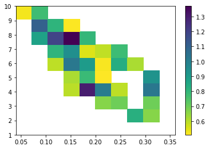

```python
plt.hist2d(data = prosper_loan, x = 'BorrowerRate', y = 'ProsperScore', cmin=0.5, cmap='viridis_r',density=True)
plt.colorbar()
```

```python
prosper_loan.Investors.value_counts()
```

```
1      26609
2       1199
3        868
4        695
5        613
       ...
736        1
622        1
685        1
621        1
582        1
Name: Investors, Length: 677, dtype: int64
```

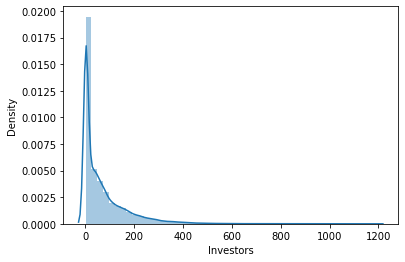

```python
sb.distplot(prosper_loan.Investors)
```

### Income Range distribuation

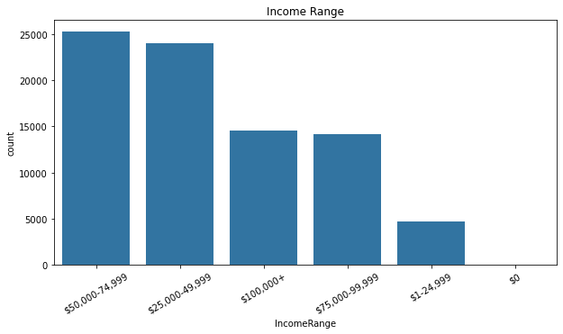

```python
plt.figure(figsize=[10,5])
sb.countplot(data=prosper_loan, x='IncomeRange',order=prosper_loan.IncomeRange.value_counts().index,
            color = base_color)
plt.xticks(rotation=30)
plt.title("Income Range");
```

- As shown 50 to 75 are most common one

```python
prosper_loan['orgination_year']=prosper_loan.LoanOriginationDate.dt.year
```

```python
prosper_loan['orgination_year'].value_counts()
```

```
2013    33537
2012    19553
2014    11524
2011    11228
2010     5579
2009     1976
Name: orgination_year, dtype: int64
```

## Year of Loan Distribuation

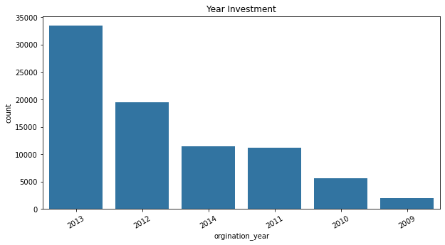

```python
plt.figure(figsize=[10,5])
sb.countplot(data=prosper_loan, x='orgination_year',order=prosper_loan.orgination_year.value_counts().index,
            color = base_color)
plt.xticks(rotation=30)
plt.title("Year Investment");
```

- This figure shows 2013 year has more loan

```python
prosper_loan['orgination_month']=prosper_loan.LoanOriginationDate.dt.month
```

## Month of Loan Distribuation vs Loan Amount

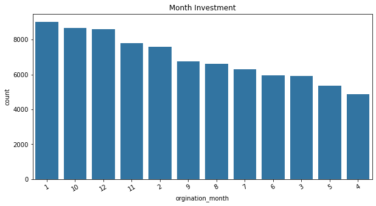

```python
plt.figure(figsize=[10,5])
sb.countplot(data=prosper_loan, x='orgination_month',order=prosper_loan.LoanOriginationDate.dt.month.value_counts().index,
            color = base_color)
plt.xticks(rotation=30)
plt.title("Month Investment");
```

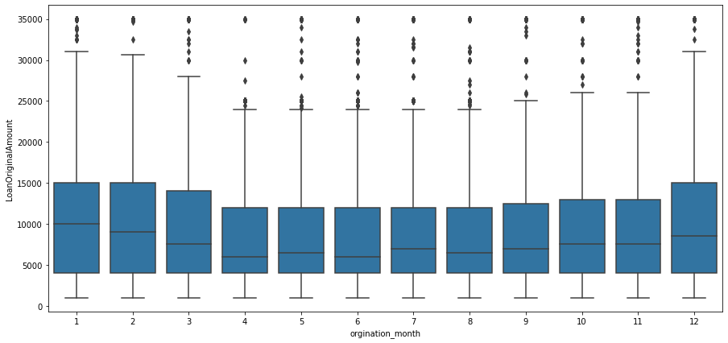

```python
plt.figure(figsize=[15,7])
sb.boxplot(data=prosper_loan,x='orgination_month',y='LoanOriginalAmount',color=base_color);
```

From Octobor to Januaray have more Loan

#### Figure Shows Fees Distribuation

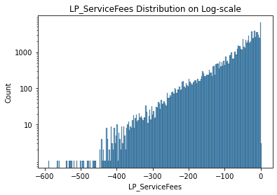

```python
sb.histplot(prosper_loan.LP_ServiceFees);
plt.yscale('log')
plt.yticks([1e1, 1e2, 1e3], ['10', '100', '1000'])
plt.title('LP_ServiceFees Distribution on Log-scale');
```

### Figure Shows States

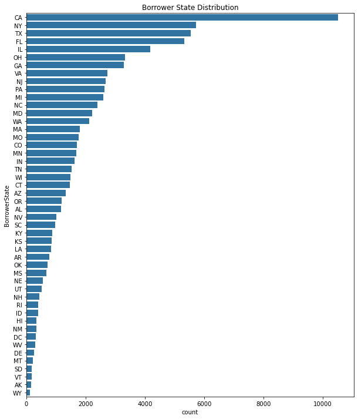

```python
plt.figure(figsize=[10,12])
sb.countplot(data=prosper_loan, y='BorrowerState',color=base_color,
            order=prosper_loan.BorrowerState.value_counts().index)
plt.title('Borrower State Distribution');
```

CA and NY have most loan

```python
numeric = ['Term', 'BorrowerAPR', 'BorrowerRate', 'LenderYield', 'ProsperScore',
                     'StatedMonthlyIncome', 'LoanOriginalAmount', 'MonthlyLoanPayment', 'LP_ServiceFees', 'Investors',
                    'AmountDelinquent','LoanCurrentDaysDelinquent']
```

```python
categorical = ['LoanStatus', 'ProsperRating (Alpha)', 'ListingCategory (numeric)', 'BorrowerState', 'Occupation',
                         'EmploymentStatus', 'IncomeRange']
```

### Summry for my data Correlation together by using Heat map

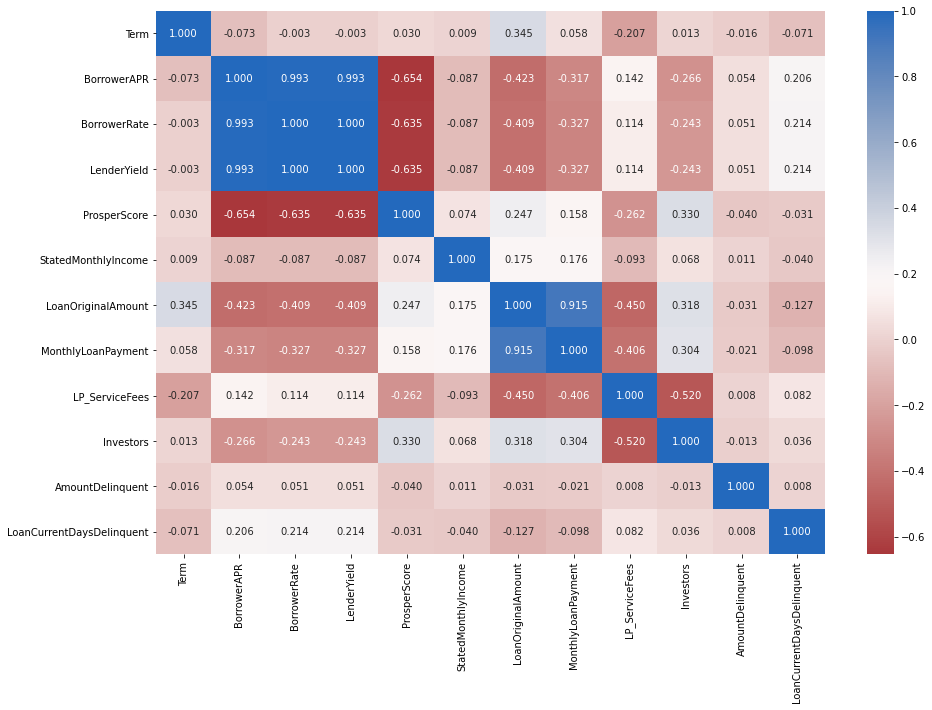

```python
plt.figure(figsize=[15,10])
sb.heatmap(data=prosper_loan[numeric].corr(),annot = True,fmt = '.3f',cmap='vlag_r');
```

### Using Viloin Plot Listing and Borrower Rate

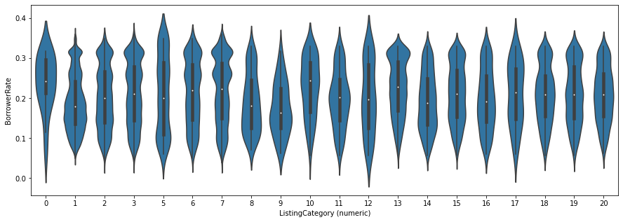

```python
plt.figure(figsize=[15,5])
sb.violinplot(data=prosper_loan, x='ListingCategory (numeric)', y='BorrowerRate', color=base_color, innner=None);
```

- We can see that Cosmetic Procedure are given higer interest rates with data distributed well in it.

### Box Plot shows Relation Loan status and Borrow Rate

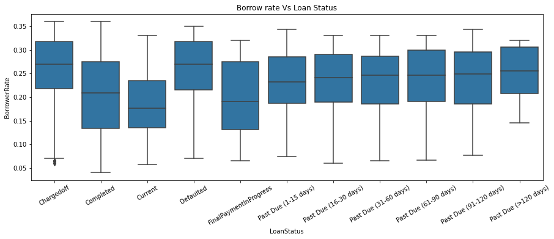

```python
plt.figure(figsize=[15,5])
sb.boxplot(data=prosper_loan,x='LoanStatus',y='BorrowerRate',color=base_color);
plt.title("Borrow rate Vs Loan Status")
plt.xticks(rotation=30);
```

### Comparison between Employed and Non

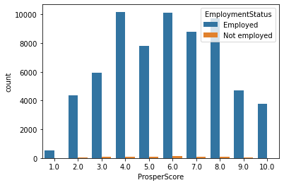

```python
sb.countplot(data = prosper_loan, x = 'ProsperScore', hue = 'EmploymentStatus',
            hue_order=['Employed','Not employed']);
```

The number of Not Employed to Employed is neglicatble

### Comparison between Term and Every State of Employment

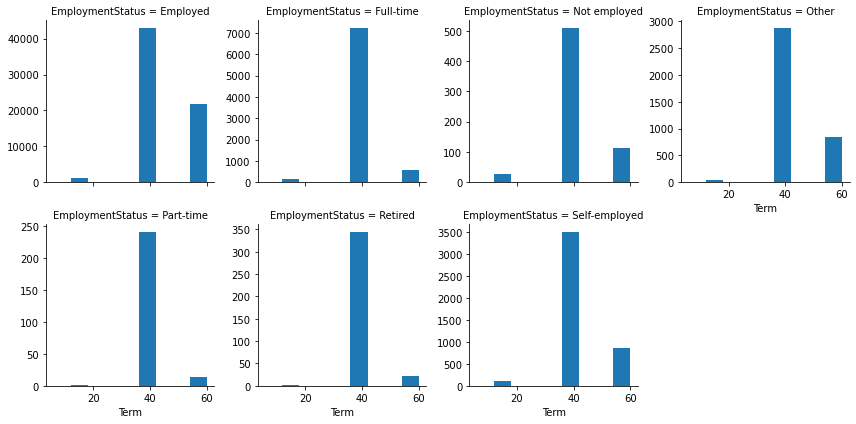

```python
bin_edges = np.arange(6, 60+6, 6)
g = sb.FacetGrid(data = prosper_loan, col = 'EmploymentStatus', col_wrap=4, sharey=False,
            margin_titles=True)
g.map(plt.hist, 'Term', bins = bin_edges);
```

this figure shows kind of statue of employeer and his Term to do it

### Pin Point for Prosper Score and Borrower APR

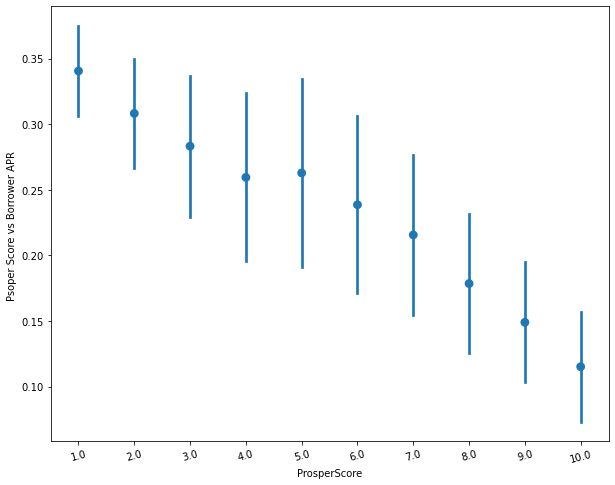

```python
plt.figure(figsize=[10,8])
sb.pointplot(data=prosper_loan, x='ProsperScore', y='BorrowerAPR', color=base_color, ci='sd', linestyles="")
plt.xticks(rotation=15);
plt.ylabel('Psoper Score vs Borrower APR ');
```

That's figure shows that when socre Increase borrower APR decrease

### Multi Variant Scatter using Lender Yield & Borrower APR vs Prosper Rating

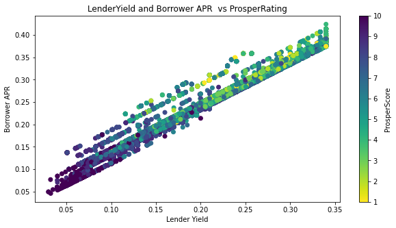

```python
plt.figure(figsize = [10, 5])
plt.scatter(data=prosper_loan,x='LenderYield',y = 'BorrowerAPR',c='ProsperScore',cmap = 'viridis_r')
plt.colorbar(label = 'ProsperScore');
plt.title('LenderYield and Borrower APR  vs ProsperRating');
plt.xlabel('Lender Yield');
plt.ylabel('Borrower APR');
```

- Between Lender Yield and Borrower APR we find positive correlation
- but between Borrower or LenderYield vs Prosper Rating we found negative correlation

### Point plot for Employment State and Prosper Rating vs Prosper Score

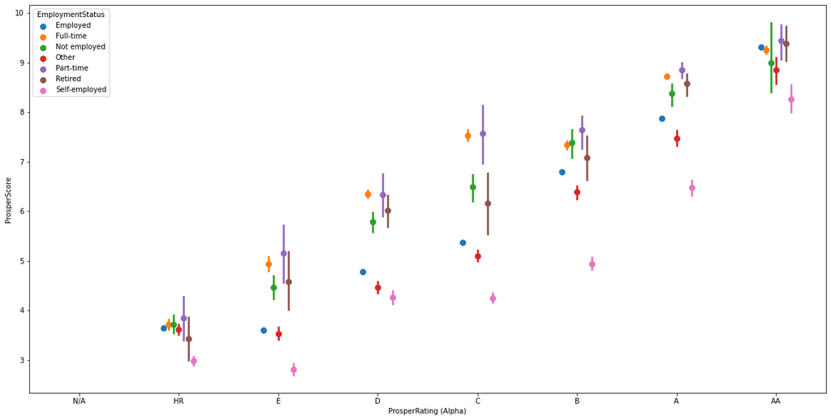

```python
plt.figure(figsize=[20,10])
ax = sb.pointplot(data = prosper_loan, x = 'ProsperRating (Alpha)', y = 'ProsperScore', hue = 'EmploymentStatus',
                  dodge = 0.3, linestyles = "")
```

### Multi Variant with Monthly Income < 20000

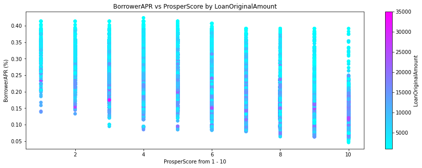

```python
plt.figure(figsize = [15, 5])
plt.scatter(data=prosper_loan[prosper_loan['StatedMonthlyIncome']<20000],
            x='ProsperScore',y='BorrowerAPR',c='LoanOriginalAmount',cmap='cool')
plt.colorbar(label = 'LoanOriginalAmount')
plt.title('BorrowerAPR vs ProsperScore by LoanOriginalAmount')
plt.xlabel('ProsperScore from 1 - 10')
plt.ylabel('BorrowerAPR (%)');
```

### Loan Original Amount and BorrowerAPR showed distributed scattering

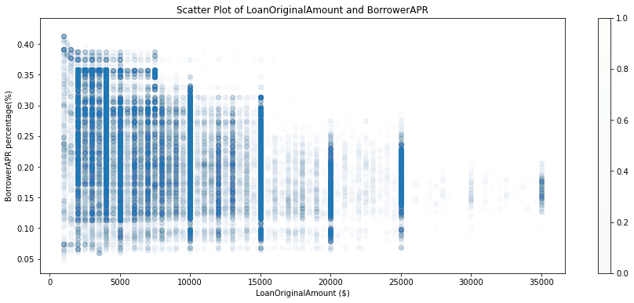

```python
plt.figure(figsize = [15, 6])
plt.scatter(data = prosper_loan, x = 'LoanOriginalAmount', y = 'BorrowerAPR',  alpha =  0.01)
plt.title('Scatter Plot of LoanOriginalAmount and BorrowerAPR')
plt.xlabel('LoanOriginalAmount ($)')
plt.ylabel('BorrowerAPR percentage(%)');
plt.colorbar();
```

We see negative relationship between loan original amount and borrower apr, means large loans have relatively less annual interest rate from the borrower.

```python
prosper_loan.LoanStatus
```

```
1                        Current
3                        Current
4                        Current
5                        Current
6                        Current
                   ...
113932                   Current
113933    FinalPaymentInProgress
113934                   Current
113935                 Completed
113936                   Current
Name: LoanStatus, Length: 83397, dtype: category
Categories (11, object): ['Chargedoff', 'Completed', 'Current', 'Defaulted', ..., 'Past Due (31-60 days)', 'Past Due (61-90 days)', 'Past Due (91-120 days)', 'Past Due (>120 days)']
```

### Figure Loan Status Vs Monthly Loan

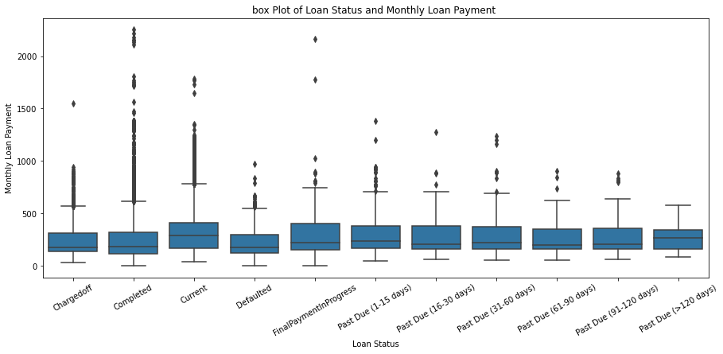

```python
plt.figure(figsize = [15, 6])
sb.boxplot(data = prosper_loan, x = 'LoanStatus', y = 'MonthlyLoanPayment',color=base_color)
plt.title('box Plot of Loan Status and Monthly Loan Payment ')
plt.xlabel('Loan Status')
plt.xticks(rotation=30)
plt.ylabel('Monthly Loan Payment');
```

### there is a lot of outliears on completed at monthly Loan Payment

```python
!jupyter nbconvert exploratory.ipynb --to slides --post serve --no-input --no-prompt
```